# QML Places API

## Overview

The Places API lets users discover places of interest and view details about them, such as address and contact information. Some places may have additional content associated with them, such as images and reviews. The Places API also lets you manage places and categories, allowing you to to save and remove them. Places may also include paths, roads, or forms of transport, enabling navigation optimization and assistance. For more information about navigation, see routes.

## Introductory Concepts

### Plugin

A Plugin is an abstraction for a backend. One Plugin might access places from a REST server while another may access places from a local database. The following instantiates a Plugin object by providing a name of "osm". The Plugin name identifies which backend to choose from. Plugins may also be provided with a set of parameters, which essentially takes the form of a set of key-value pairs. The parameters that can be specified vary among the different Plugin backends. For documentation on the possible parameters and nuances of each Plugin, see the Plugin References.

```
Plugin {
    id: myPlugin
    name: "osm"
    //specify plugin parameters as necessary
    //PluginParameter {...}
    //PluginParameter {...}
    //...
}
```

### Models, Views and Delegates

The QML Places API is built around the notion of models, views and delegates.

[output not shown]

The Common Use Cases section below demonstrates concrete examples of how these concepts fit together.

## Common Use Cases

### Searching for Places

Searching is accomplished via the PlaceSearchModel. The plugin property specifies which backend to perform search operations against. Search parameters may be provided through properties such as the searchTerm and searchArea. A search operation can then be started by invoking the update() method. For simplicity, the snippet below invokes update() once construction of the model as been completed, typically update() would be invoked in response to a user action such as a button click. While the search operation is underway the PlaceSearchModel::status property transitions into the `Loading` state and when successfully completed moves into the `Ready` state.

```
PlaceSearchModel {
    id: searchModel

    plugin: myPlugin

    searchTerm: "food"
    searchArea: QtPositioning.circle(startCoordinate, 5000 /* 5 km radius */);

    Component.onCompleted: update()

}
```

### Display Search Results using a ListView

A ListView can be used to show the search results found by the model. It defines the visual region for where the results are shown, and in the case below fills the entirety of its parent. The ListView has built in behavior that enables the region to respond to flicking events and to scroll appropriately.

In the snippet below, the search model has been assigned to the ListView's model property. When the model is updated with new results, the ListView is automatically updated to reflect the model's new data items.

A simple delegate has been bound to the ListView's delegate property. The PlaceSearchModel exposes a set of roles of which the *title* and *place* roles have been used below, these are of type string and Place respectively. Essentially for each data item that should be visible in the view, the view invokes the delegate to create a visual representation of the item.

```
ListView {
    anchors.fill: parent
    model: searchModel
    delegate: Component {
        Row {
            spacing: 5
            Marker { height: parent.height }
            Column {
                Text { text: title; font.bold: true }
                Text { text: place.location.address.text }
            }
        }
    }
}
```

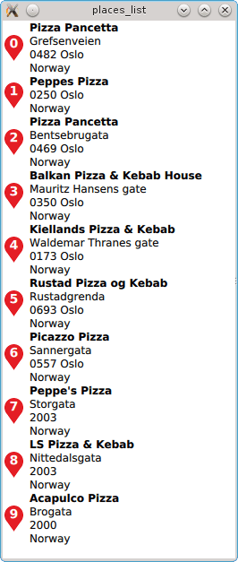

**Note:** For simplicty's sake we have assumed that every search result is of type `PlaceSearchResult` and so always have access to the *place* role, other search result types may not have a *place* role.

See the [Places List](https://doc.qt.io/qt-6.9/qtlocation-places-list-example.html) example for full source code.

### Display Search Results using a MapItemView

Instead of a ListView, the PlaceSearchModel can be used in conjunction with a MapItemView to display markers on a map. Firstly a Map is used to define the visual region occupied by the map, in this case it fills the entirety of its parent. Other properties are specified such as the plugin providing the maps, and the map's center and zoomLevel.

Inside the Map, a MapItemView is declared, where the model property has been set to the search model and a delegate consisting of a MapQuickItem is used to display a marker image. A marker is shown for every place that was found by the search model. The delegate uses the *place* role to position the marker.

```
MapView {
    id: view
    anchors.fill: parent
    map.plugin: myPlugin;
    map.center: positionSource.lastSearchPosition
    map.zoomLevel: 13

    MapItemView {
        model: searchModel
        parent: view.map
        delegate: MapQuickItem {
            coordinate: place.location.coordinate

            anchorPoint.x: image.width * 0.5
            anchorPoint.y: image.height

            sourceItem: Column {
                Image { id: image; source: "marker.png" }
                Text { text: title; font.bold: true }
            }
        }
    }
}
```

[figure not shown]

**Note:** For simplicty's sake we have assumed that every search result is of type `PlaceSearchResult` and so always have access to the *place* role, other search result types may not have a *place* role.

See the [Places Map](https://doc.qt.io/qt-6.9/qtlocation-places-map-example.html) example for full source code.

### Fetching Place Details

In order to save bandwidth, sometimes a backend will only return places which are partially populated with details. This can be checked with the Place::detailsFetched property which indicates whether all availalable details have been fetched or not. If not, the Place::getDetails() method can be invoked to fetch the remaining details.

```
if (!place.detailsFetched)
    place.getDetails();
```

### Saving and Removing Places

Some backends may support saving and removing places. This can be done by calling the Place::save() and Place::remove() methods respectively. Note that in order to save a Place, a Plugin must be assigned to specify which backend we are saving to. The status property will transition into the `Saving` state while the save operation is happening and on successful completion will move to the `Ready` state. The following snippet shows how to save and remove a place using javascript.

```
//creating and saving a place
var place = Qt.createQmlObject('import QtLocation; Place { }', parent);
place.plugin = myPlugin;
place.name = "New York";
place.location.coordinate.latitude = 40.7
place.location.coordinate.longitude = -74.0
place.save();

//removing a place
place.remove();
```

### Learn More

The above snippets only exhibit a small subset of Places functionality. Refer to the Places Types shown below for richer content such as images, reviews etc, as well as more indepth descriptions and explanations.

See also the [Places (QML)](https://doc.qt.io/qt-6.9/qtlocation-places-example.html) example for a more comprehensive demonstration on how to use the API.

## Places Types

### Data Types

| Category | Type represents a category that a Place can be associated with |
| --- | --- |
| ContactDetails | Type holds contact details for a Place |
| ExtendedAttributes | Type holds additional data about a Place |
| Place | Type represents a location that is a position of interest |
| contactDetail | Type holds a contact detail such as a phone number or a website address |
| icon | Type represents the icon of a place |
| placeAttribute | Type holds generic place attribute information |
| ratings | Type holds place rating information |
| supplier | Holds data regarding the supplier of a place, a place's image, review, or editorial |
| user | Type identifies a user who contributed a particular Place content item |

### Models

| CategoryModel | Type provides a model of the categories supported by a Plugin |
| --- | --- |
| EditorialModel | Type provides a model of place editorials |
| ImageModel | Type provides a model of place images |
| PlaceSearchModel | Provides access to place search results |
| PlaceSearchSuggestionModel | Provides access to search term suggestions |
| ReviewModel | Type provides a model of place reviews |

Places (C++) Places Backend

© The Qt Company Ltd  
Licensed under the GNU Free Documentation License, Version 1.3.  
https://doc.qt.io/qt-6.9/location-places-qml.html